# R Notebook

# Laboratorio 3

```r
library(dplyr)
library(ggplot2)
library(corrplot)
library(PerformanceAnalytics)
```

# Problema 1

Utilizando R realice una función que dado un dataframe cualquiera de dos columnas, donde la primera (índice 1) sea el valor de la variable independiente (X) y la segunda sea el valor de una variable dependiente (Y), devuelva una lista con los siguientes elementos:

1. Un arreglo con los valores de los estimadores para coeficiente e intercepto
2. El valor del coeficiente de determinación del modelo.
3. El coeficiente de correlación r (raíz cuadrada del inciso anterior).
4. Un arreglo con los valores de los residuos.
5. Una gráfica con la nube de puntos y la recta de regresión del modelo.

```r
### Generando dataset

set.seed(70)


Xinventada <- rnorm(300,30,1000)
error <- rnorm(300, 100,10000)
yinventada <- 25*X + 10 + error
df <- data.frame(X =Xinventada,Y = yinventada)
df
```

| X | Y |
| --- | --- |
| -1511.771383 | -35801.56440 |
| 376.941803 | 25606.96876 |
| 1129.437900 | 31376.47710 |
| -468.567261 | 36.10380 |
| -908.331458 | -27741.97449 |
| -102.316152 | 9279.44334 |
| 305.811691 | 2904.78003 |
| -374.915005 | -9030.58630 |
| -1666.475293 | -28901.55097 |
| 424.439042 | 5165.28222 |

[output cut: 290 more lines]

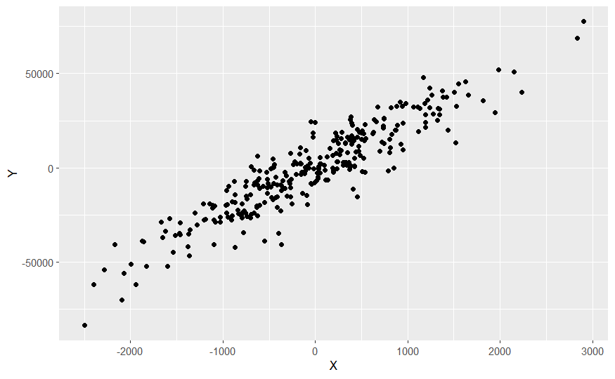

```r
ggplot(data = df, aes(x = X, y = Y)) +
  geom_point()
```

```r
modelo <- function(df1){
  ### Coeficientes
  xmod <- df1$X
  ymod <- df1$Y
  m <- (length(xmod)*sum(xmod*ymod)-sum(xmod)*sum(ymod))/(length(xmod)*sum(xmod^2)-(sum(xmod))^2)
  b <- mean(ymod) - m*mean(xmod)
  ### R2 y R
  yestimada <- m*xmod + b
  R2 = sum((yestimada - mean(ymod))^2)/sum((ymod - mean(ymod))^2)
  R = sqrt(R2)
  ### Residuos
  residuos = ymod - yestimada
  ### Gráfica
  plot(xmod, ymod, main = 'Gráfica modelo', xlab = 'X', ylab = 'Y', col = 'orange3', pch = 19)
  abline( a = b, b = m, col = 'purple4', lwd = 3 )
  ##Return
  DataModelo <- list(coefs = list(coef = m, intercept = b), R2 = R2, R = R, Residuals = residuos)
  return(DataModelo)
}
```

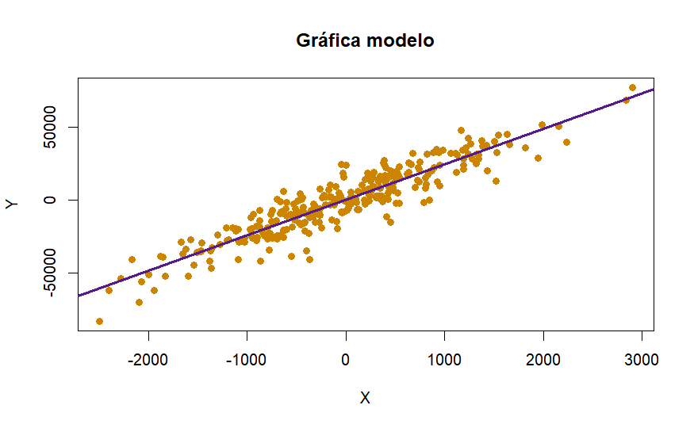

```r
### Probando el modelo
lmmodelo <- modelo(df)
```

```r
## Grafica
  #ggplot(data = df, aes(x = X, y = Y)) +
    #geom_point(col = 'orange3') +
    #geom_abline(slope = lmmodelo$coefs$coef, intercept = lmmodelo$coefs$intercept, lwd = 1, col = 'purple4')+
    #theme_linedraw()
```

```r
lmmodelo
```

```
$coefs
$coefs$coef
[1] 24.33358

$coefs$intercept
[1] 385.2335


$R2
[1] 0.854352

$R
[1] 0.9243117

$Residuals
```

[output cut: 34 more lines]

# Problema 2

Para este ejercicio se le solicita que desarrolle las siguientes actividades utilizando RStudio Con el dataset Admissions adjunto a este laboratorio realice lo siguiente:

```r
DataAdmis <- read.csv('Admisions.csv')
head(DataAdmis)
```

|  | Serial.No. | GRE.Score | TOEFL.Score | University.Rating | SOP | LOR | CGPA | Research | Chance.of.Admit |
| --- | --- | --- | --- | --- | --- | --- | --- | --- | --- |
| 1 | 1 | 337 | 118 | 4 | 4.5 | 4.5 | 9.65 | 1 | 0.92 |
| 2 | 2 | 324 | 107 | 4 | 4.0 | 4.5 | 8.87 | 1 | 0.76 |
| 3 | 3 | 316 | 104 | 3 | 3.0 | 3.5 | 8.00 | 1 | 0.72 |
| 4 | 4 | 322 | 110 | 3 | 3.5 | 2.5 | 8.67 | 1 | 0.80 |
| 5 | 5 | 314 | 103 | 2 | 2.0 | 3.0 | 8.21 | 0 | 0.65 |
| 6 | 6 | 330 | 115 | 5 | 4.5 | 3.0 | 9.34 | 1 | 0.90 |

1. Realice un análisis estadístico sobre todas las variables del dataset, recuerde que pude usar la función summary().

```r
Admis <- DataAdmis %>%
  select(-Serial.No.)
Admis
```

| GRE.Score | TOEFL.Score | University.Rating | SOP | LOR | CGPA | Research | Chance.of.Admit |
| --- | --- | --- | --- | --- | --- | --- | --- |
| 337 | 118 | 4 | 4.5 | 4.5 | 9.65 | 1 | 0.92 |
| 324 | 107 | 4 | 4.0 | 4.5 | 8.87 | 1 | 0.76 |
| 316 | 104 | 3 | 3.0 | 3.5 | 8.00 | 1 | 0.72 |
| 322 | 110 | 3 | 3.5 | 2.5 | 8.67 | 1 | 0.80 |
| 314 | 103 | 2 | 2.0 | 3.0 | 8.21 | 0 | 0.65 |
| 330 | 115 | 5 | 4.5 | 3.0 | 9.34 | 1 | 0.90 |
| 321 | 109 | 3 | 3.0 | 4.0 | 8.20 | 1 | 0.75 |
| 308 | 101 | 2 | 3.0 | 4.0 | 7.90 | 0 | 0.68 |
| 302 | 102 | 1 | 2.0 | 1.5 | 8.00 | 0 | 0.50 |
| 323 | 108 | 3 | 3.5 | 3.0 | 8.60 | 0 | 0.45 |

[output cut: 490 more lines]

```r
summary(Admis)
```

```
   GRE.Score      TOEFL.Score    University.Rating      SOP             LOR             CGPA          Research
 Min.   :290.0   Min.   : 92.0   Min.   :1.000     Min.   :1.000   Min.   :1.000   Min.   :6.800   Min.   :0.00
 1st Qu.:308.0   1st Qu.:103.0   1st Qu.:2.000     1st Qu.:2.500   1st Qu.:3.000   1st Qu.:8.127   1st Qu.:0.00
 Median :317.0   Median :107.0   Median :3.000     Median :3.500   Median :3.500   Median :8.560   Median :1.00
 Mean   :316.5   Mean   :107.2   Mean   :3.114     Mean   :3.374   Mean   :3.484   Mean   :8.576   Mean   :0.56
 3rd Qu.:325.0   3rd Qu.:112.0   3rd Qu.:4.000     3rd Qu.:4.000   3rd Qu.:4.000   3rd Qu.:9.040   3rd Qu.:1.00
 Max.   :340.0   Max.   :120.0   Max.   :5.000     Max.   :5.000   Max.   :5.000   Max.   :9.920   Max.   :1.00
 Chance.of.Admit
 Min.   :0.3400
 1st Qu.:0.6300
 Median :0.7200
 Mean   :0.7217
 3rd Qu.:0.8200
 Max.   :0.9700
```

```r
sapply(Admis, sd)
```

```
        GRE.Score       TOEFL.Score University.Rating               SOP               LOR              CGPA          Research
       11.2951484         6.0818677         1.1435118         0.9910036         0.9254496         0.6048128         0.4968841
  Chance.of.Admit
        0.1411404
```

2. Realice una gráfica de densidad para cada una de las variables numéricas en el dataset: GRE.Score, TOEFEL.Score, CGPA y Chance of Admit.

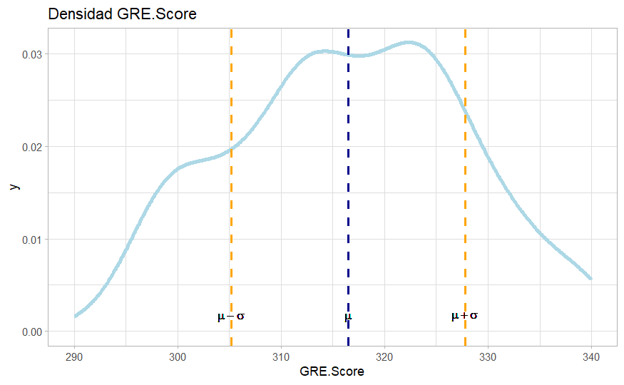

```r
### Gráfica densidad GRE.Score

ggplot(data = Admis, aes(x = GRE.Score)) +
  geom_density(stat = 'density', col = 'lightblue', lwd = 1.5)+
  geom_vline(aes(xintercept = mean(GRE.Score)), col = 'darkblue', lwd = 1, linetype = 'dashed') +
  geom_vline(aes(xintercept = (mean(GRE.Score)+ sd(GRE.Score))), col = 'orange', lwd = 0.9, linetype = 'dashed') +
  geom_vline(aes(xintercept = (mean(GRE.Score)- sd(GRE.Score))), col = 'orange', lwd = 0.9, linetype = 'dashed') +
  theme_light() + ggtitle('Densidad GRE.Score')+
  geom_text(aes(mean(GRE.Score),0,label = 'mu', vjust = -1), parse = TRUE) +
  geom_text(aes((mean(GRE.Score)- sd(GRE.Score)),0,label = paste('mu', '-', 'sigma') , vjust = -1), parse = TRUE) +
geom_text(aes((mean(GRE.Score)+ sd(GRE.Score)),0,label = paste('mu', '+', 'sigma') , vjust = -1), parse = TRUE)
```

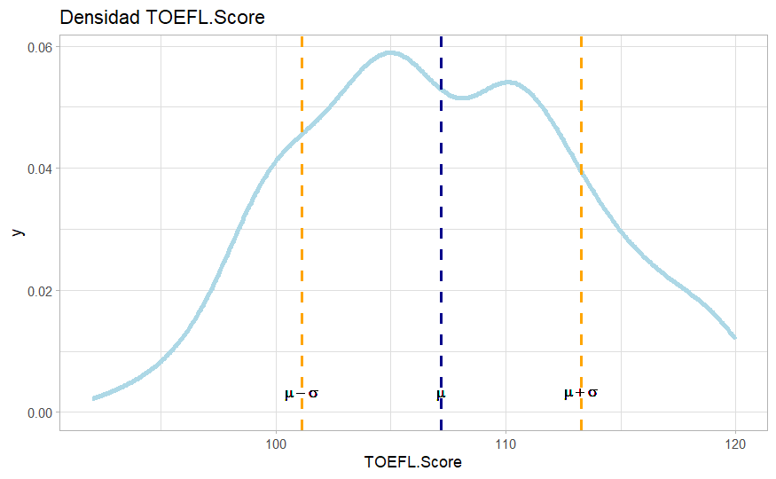

```r
### Gráfica de TOEFL.Score
ggplot(data = Admis, aes(x = TOEFL.Score)) +
  geom_density(stat = 'density', col = 'lightblue', lwd = 1.5)+
  geom_vline(aes(xintercept = mean(TOEFL.Score)), col = 'darkblue', lwd = 1, linetype = 'dashed') +
  geom_vline(aes(xintercept = (mean(TOEFL.Score)+ sd(TOEFL.Score))), col = 'orange', lwd = 0.9, linetype = 'dashed') +
  geom_vline(aes(xintercept = (mean(TOEFL.Score)- sd(TOEFL.Score))), col = 'orange', lwd = 0.9, linetype = 'dashed') +
  theme_light() + ggtitle('Densidad TOEFL.Score') +
  geom_text(aes(mean(TOEFL.Score),0,label = 'mu', vjust = -1), parse = TRUE) +
  geom_text(aes((mean(TOEFL.Score)- sd(TOEFL.Score)),0,label = paste('mu', '-', 'sigma') , vjust = -1), parse = TRUE) +
  geom_text(aes((mean(TOEFL.Score)+ sd(TOEFL.Score)),0,label = paste('mu', '+', 'sigma') , vjust = -1), parse = TRUE)
```

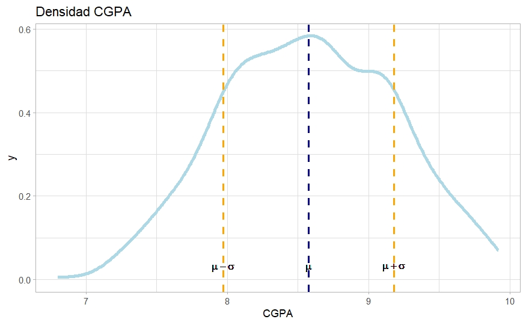

```r
### Gráfica CGPA
ggplot(data = Admis, aes(x = CGPA)) +
  geom_density(stat = 'density', col = 'lightblue', lwd = 1.5)+
  geom_vline(aes(xintercept = mean(CGPA)), col = 'darkblue', lwd = 1, linetype = 'dashed') +
  geom_vline(aes(xintercept = (mean(CGPA)+ sd(CGPA))), col = 'orange', lwd = 0.9, linetype = 'dashed') +
  geom_vline(aes(xintercept = (mean(CGPA)- sd(CGPA))), col = 'orange', lwd = 0.9, linetype = 'dashed') +
  theme_light() + ggtitle('Densidad CGPA') +
  geom_text(aes(mean(CGPA),0,label = 'mu', vjust = -1), parse = TRUE) +
  geom_text(aes((mean(CGPA)- sd(CGPA)),0,label = paste('mu', '-', 'sigma') , vjust = -1), parse = TRUE) +
  geom_text(aes((mean(CGPA)+ sd(CGPA)),0,label = paste('mu', '+', 'sigma') , vjust = -1), parse = TRUE)
```